# EDA — Manutenção Prescritiva SENAI/FIESC

```python
import numpy as np
import pandas as pd
import matplotlib.pyplot as plt
import seaborn as sns
from sklearn.preprocessing import StandardScaler, LabelEncoder, label_binarize
from sklearn.model_selection import train_test_split, GridSearchCV
from sklearn.neighbors import KNeighborsClassifier
from sklearn.metrics import (
    classification_report, confusion_matrix,
    roc_curve, auc, roc_auc_score
)

%matplotlib inline
sns.set_theme(style='whitegrid')
pd.set_option('display.max_columns', 30)
```

```python
FEATURE_COLS = [
    'z_rms_velocity_in_s', 'z_rms_velocity_mm_s', 'temperature_f', 'temperature_c',
    'x_rms_velocity_in_s', 'x_rms_velocity_mm_s', 'z_peak_acceleration_g',
    'x_peak_acceleration_g', 'z_peak_vel_comp_freq_hz', 'x_peak_vel_comp_freq_hz',
    'z_rms_acceleration_g', 'x_rms_acceleration_g', 'z_kurtosis', 'x_kurtosis',
    'z_crest_factor', 'x_crest_factor', 'z_peak_velocity_in_s', 'z_peak_velocity_mm_s',
    'x_peak_velocity_in_s', 'x_peak_velocity_mm_s', 'z_high_freq_rms_accel_g',
    'x_high_freq_rms_accel_g', 'rpm',
]

df = pd.read_parquet('../data/banner_clean.parquet')
df.head()
```

|  | id | created_at | z_rms_velocity_in_s | z_rms_velocity_mm_s | temperature_f | temperature_c | x_rms_velocity_in_s | x_rms_velocity_mm_s | z_peak_acceleration_g | x_peak_acceleration_g | z_peak_vel_comp_freq_hz | x_peak_vel_comp_freq_hz | z_rms_acceleration_g | x_rms_acceleration_g | z_kurtosis | x_kurtosis | z_crest_factor | x_crest_factor | z_peak_velocity_in_s | z_peak_velocity_mm_s | x_peak_velocity_in_s | x_peak_velocity_mm_s | z_high_freq_rms_accel_g | x_high_freq_rms_accel_g | fault | rpm | fault_canonical | is_problem | documented |
| --- | --- | --- | --- | --- | --- | --- | --- | --- | --- | --- | --- | --- | --- | --- | --- | --- | --- | --- | --- | --- | --- | --- | --- | --- | --- | --- | --- | --- | --- |
| 0 | 1426 | 2026-04-30 17:17:41.549800+00:00 | 0.0427 | 1.086 | 74.00 | 23.33 | 0.0619 | 1.573 | 0.031 | 0.033 | 61.0 | 61.0 | 0.046 | 0.066 | 3.276 | 3.250 | 4.435 | 3.918 | 0.0605 | 1.536 | 0.0875 | 2.224 | 0.007 | 0.008 | motor_desligado | 0.0 | motor_desligado | False | False |
| 1 | 1427 | 2026-04-30 17:17:43.549806+00:00 | 0.0431 | 1.095 | 73.91 | 23.28 | 0.0622 | 1.581 | 0.039 | 0.040 | 61.0 | 61.0 | 0.046 | 0.067 | 3.447 | 3.449 | 5.460 | 4.924 | 0.0609 | 1.549 | 0.0880 | 2.236 | 0.007 | 0.008 | motor_desligado | 0.0 | motor_desligado | False | False |
| 2 | 1428 | 2026-04-30 17:17:45.550674+00:00 | 0.0431 | 1.095 | 74.00 | 23.33 | 0.0622 | 1.581 | 0.039 | 0.040 | 61.0 | 61.0 | 0.046 | 0.067 | 3.447 | 3.449 | 5.460 | 4.924 | 0.0609 | 1.549 | 0.0880 | 2.236 | 0.007 | 0.008 | motor_desligado | 0.0 | motor_desligado | False | False |
| 3 | 1429 | 2026-04-30 17:17:47.551119+00:00 | 0.0431 | 1.096 | 74.00 | 23.33 | 0.0617 | 1.568 | 0.070 | 0.100 | 61.0 | 61.0 | 0.046 | 0.066 | 7.921 | 15.372 | 9.068 | 10.929 | 0.0610 | 1.550 | 0.0873 | 2.218 | 0.007 | 0.009 | motor_desligado | 0.0 | motor_desligado | False | False |
| 4 | 1430 | 2026-04-30 17:17:49.553252+00:00 | 0.0440 | 1.119 | 73.96 | 23.31 | 0.0615 | 1.563 | 0.031 | 0.049 | 61.0 | 61.0 | 0.047 | 0.066 | 3.245 | 3.956 | 4.265 | 5.949 | 0.0623 | 1.583 | 0.0870 | 2.210 | 0.007 | 0.008 | motor_desligado | 0.0 | motor_desligado | False | False |

```python
print('Shape:', df.shape)
df.dtypes
```

```
Shape: (166796, 29)
```

```
id                                       int64
created_at                 datetime64[us, UTC]
z_rms_velocity_in_s                    float64
z_rms_velocity_mm_s                    float64
temperature_f                          float64
temperature_c                          float64
x_rms_velocity_in_s                    float64
x_rms_velocity_mm_s                    float64
z_peak_acceleration_g                  float64
x_peak_acceleration_g                  float64
z_peak_vel_comp_freq_hz                float64
x_peak_vel_comp_freq_hz                float64
z_rms_acceleration_g                   float64
x_rms_acceleration_g                   float64
z_kurtosis                             float64
x_kurtosis                             float64
z_crest_factor                         float64
x_crest_factor                         float64
z_peak_velocity_in_s                   float64
z_peak_velocity_mm_s                   float64
x_peak_velocity_in_s                   float64
x_peak_velocity_mm_s                   float64
z_high_freq_rms_accel_g                float64
x_high_freq_rms_accel_g                float64
fault                                      str
rpm                                    float64
fault_canonical                            str
is_problem                                bool
documented                                bool
dtype: object
```

```python
df.isnull().sum()
```

```
id                         0
created_at                 0
z_rms_velocity_in_s        0
z_rms_velocity_mm_s        0
temperature_f              0
temperature_c              0
x_rms_velocity_in_s        0
x_rms_velocity_mm_s        0
z_peak_acceleration_g      0
x_peak_acceleration_g      0
z_peak_vel_comp_freq_hz    0
x_peak_vel_comp_freq_hz    0
z_rms_acceleration_g       0
x_rms_acceleration_g       0
z_kurtosis                 0
x_kurtosis                 0
z_crest_factor             0
x_crest_factor             0
z_peak_velocity_in_s       0
z_peak_velocity_mm_s       0
x_peak_velocity_in_s       0
x_peak_velocity_mm_s       0
z_high_freq_rms_accel_g    0
x_high_freq_rms_accel_g    0
fault                      0
rpm                        0
fault_canonical            0
is_problem                 0
documented                 0
dtype: int64
```

## Qual a distribuição dos defeitos?

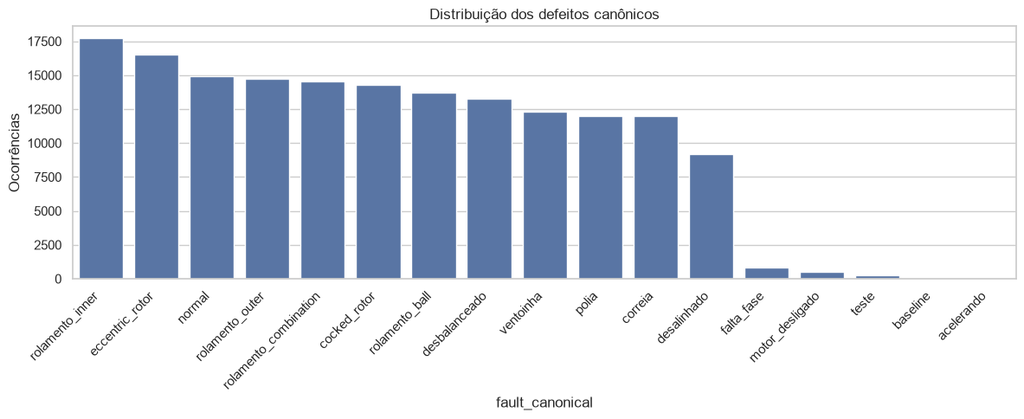

```
                           n   pct
fault_canonical
rolamento_inner        17712  10.6
eccentric_rotor        16497   9.9
normal                 14958   9.0
rolamento_outer        14763   8.9
rolamento_combination  14550   8.7
cocked_rotor           14275   8.6
rolamento_ball         13704   8.2
desbalanceado          13237   7.9
ventoinha              12299   7.4
polia                  12000   7.2
correia                11999   7.2
desalinhado             9178   5.5
falta_fase               800   0.5
motor_desligado          497   0.3
teste                    251   0.2
baseline                  69   0.0
acelerando                 7   0.0
```

```python
counts = df['fault_canonical'].value_counts()

plt.figure(figsize=(12, 5))
sns.barplot(x=counts.index, y=counts.values)
plt.xticks(rotation=45, ha='right')
plt.ylabel('Ocorrências')
plt.title('Distribuição dos defeitos canônicos')
plt.tight_layout()
plt.show()

print(counts.to_frame('n').assign(pct=lambda x: (x['n'] / x['n'].sum() * 100).round(1)))
```

Leve desbalanceamento: `rolamento_inner` lidera com 10,6% e `acelerando` tem apenas 7 registros (0,004%). Estados operacionais normais (`normal`, `baseline`, `acelerando`, `motor_desligado`) são minoria — o dataset é predominantemente de defeitos reais.

## Como se distribuem as principais features de vibração?

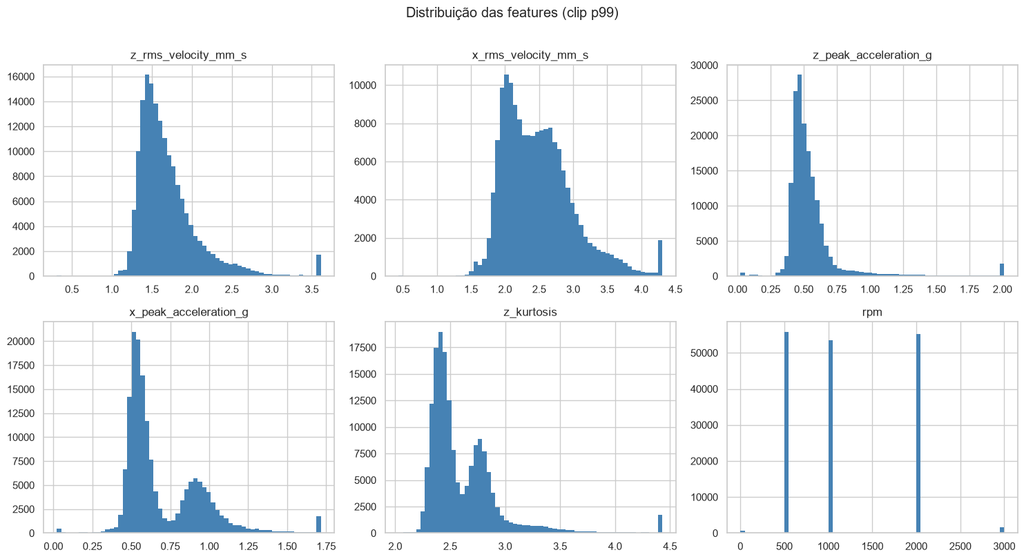

```python
features_plot = [
    'z_rms_velocity_mm_s', 'x_rms_velocity_mm_s',
    'z_peak_acceleration_g', 'x_peak_acceleration_g',
    'z_kurtosis', 'rpm'
]

fig, axes = plt.subplots(2, 3, figsize=(15, 8))
for ax, feat in zip(axes.flatten(), features_plot):
    clip_val = df[feat].quantile(0.99)
    ax.hist(df[feat].clip(upper=clip_val), bins=60, edgecolor='none', color='steelblue')
    ax.set_title(feat)
    ax.set_xlabel('')
plt.suptitle('Distribuição das features (clip p99)', y=1.01)
plt.tight_layout()
plt.show()
```

## Existe correlação entre as features?

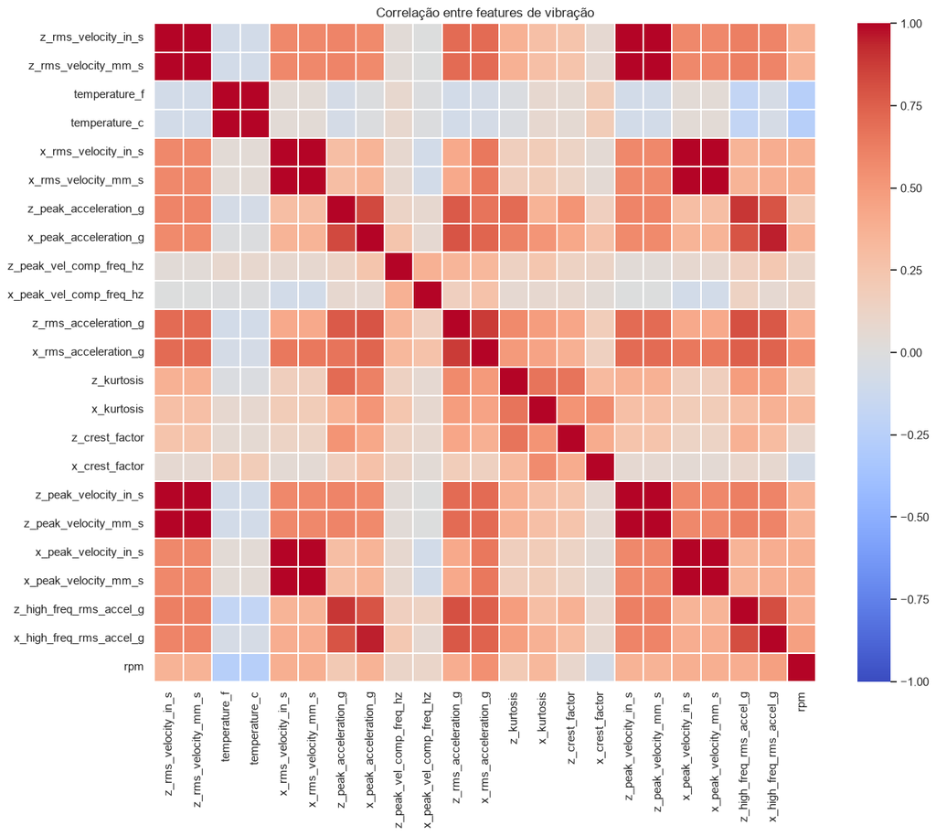

|  | feat_a | feat_b | corr |
| --- | --- | --- | --- |
| 40 | z_rms_velocity_mm_s | z_peak_velocity_mm_s | 1.000000 |
| 134 | x_rms_velocity_mm_s | x_peak_velocity_mm_s | 1.000000 |
| 385 | z_peak_velocity_in_s | z_peak_velocity_mm_s | 1.000000 |
| 39 | z_rms_velocity_mm_s | z_peak_velocity_in_s | 1.000000 |
| 433 | x_peak_velocity_in_s | x_peak_velocity_mm_s | 1.000000 |
| 133 | x_rms_velocity_mm_s | x_peak_velocity_in_s | 0.999999 |
| 17 | z_rms_velocity_in_s | z_peak_velocity_mm_s | 0.999999 |
| 1 | z_rms_velocity_in_s | z_rms_velocity_mm_s | 0.999999 |
| 16 | z_rms_velocity_in_s | z_peak_velocity_in_s | 0.999999 |
| 111 | x_rms_velocity_in_s | x_peak_velocity_mm_s | 0.999999 |
| 97 | x_rms_velocity_in_s | x_rms_velocity_mm_s | 0.999999 |
| 49 | temperature_f | temperature_c | 0.999999 |
| 110 | x_rms_velocity_in_s | x_peak_velocity_in_s | 0.999999 |
| 182 | x_peak_acceleration_g | x_high_freq_rms_accel_g | 0.951322 |

```python
plt.figure(figsize=(13, 11))
corr = df[FEATURE_COLS].corr()
sns.heatmap(corr, annot=False, cmap='coolwarm', linewidths=0.2, vmin=-1, vmax=1)
plt.title('Correlação entre features de vibração')
plt.xticks(rotation=90)
plt.tight_layout()
plt.show()

# Pares com alta correlação (> 0.9)
high = (
    corr.where(np.triu(np.ones(corr.shape), k=1).astype(bool))
    .stack()
    .reset_index()
)
high.columns = ['feat_a', 'feat_b', 'corr']
high[high['corr'].abs() > 0.9].sort_values('corr', ascending=False)
```

Pares `*_in_s` / `*_mm_s` têm correlação 1.0 — são a mesma métrica em unidades diferentes. PCA ou seleção de features pode reduzir esta redundância sem perda de informação.

## Como varia o RPM por defeito?

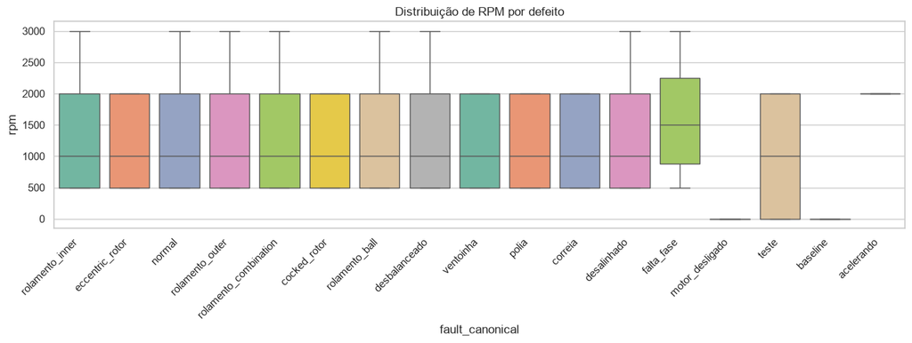

```python
ordem = df['fault_canonical'].value_counts().index

plt.figure(figsize=(13, 5))
sns.boxplot(data=df, x='fault_canonical', y='rpm', order=ordem, palette='Set2')
plt.xticks(rotation=45, ha='right')
plt.title('Distribuição de RPM por defeito')
plt.tight_layout()
plt.show()
```

## As 4 Métricas do Sistema de Manutenção Prescritiva

O sistema retorna, para cada novo evento, as 4 informações exigidas no enunciado:

| # | Métrica | Campo no sistema |
| --- | --- | --- |
| ① | Quantidade de eventos similares registrados | `n_similar` |
| ② | Distribuição ao longo do tempo | `time_distribution` (mês → contagem) |
| ③ | Frequência de ocorrência | `frequency_per_week` |
| ④ | Contexto operacional associado | RPM médio por categoria de defeito |

Visualização sobre o dataset completo (166k eventos):

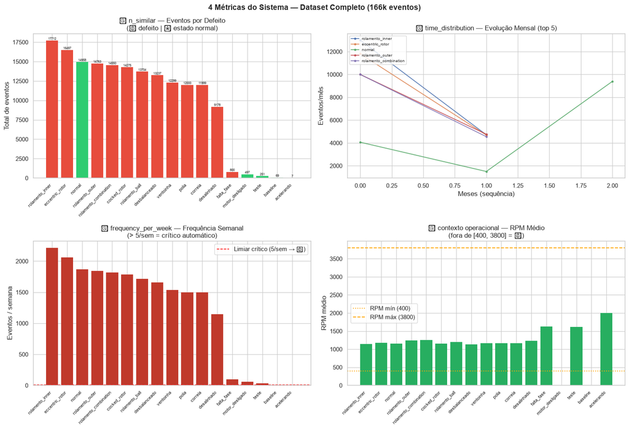

```
Resumo:
① 17 tipos de defeito/estado | 166,796 eventos totais
② 2026-04 → 2026-06 (3 meses de dados)
③ Mais frequente: rolamento_inner (2214.0 eventos/semana)
④ RPM médio em defeitos: 1186 rpm
```

```python
fig, axes = plt.subplots(2, 2, figsize=(16, 11))
fig.suptitle('4 Métricas do Sistema — Dataset Completo (166k eventos)', fontsize=14, fontweight='bold')

df_t = df.copy()
df_t['mes'] = pd.to_datetime(df_t['created_at']).dt.to_period('M').astype(str)
df_t['semana'] = pd.to_datetime(df_t['created_at']).dt.to_period('W').astype(str)
total_semanas = df_t['semana'].nunique()

# ① n_similar — contagem total por defeito (proxy de "quantos similares existem")
ax = axes[0, 0]
n_sim = df['fault_canonical'].value_counts()
colors = ['#e74c3c' if df[df['fault_canonical'] == f]['is_problem'].any() else '#2ecc71'
          for f in n_sim.index]
ax.bar(range(len(n_sim)), n_sim.values, color=colors, edgecolor='none')
ax.set_xticks(range(len(n_sim)))
ax.set_xticklabels(n_sim.index, rotation=45, ha='right', fontsize=8)
ax.set_title('① n_similar — Eventos por Defeito\n(🔴 defeito | 🟢 estado normal)')
ax.set_ylabel('Total de eventos')
for i, v in enumerate(n_sim.values):
    ax.text(i, v + 100, str(v), ha='center', fontsize=6)

# ② time_distribution — evolução mensal dos top 5 defeitos
ax = axes[0, 1]
top5 = df['fault_canonical'].value_counts().head(5).index
for fault in top5:
    serie = df_t[df_t['fault_canonical'] == fault].groupby('mes').size()
    meses = list(range(len(serie)))
    ax.plot(meses, serie.values, marker='o', markersize=3, linewidth=1.5,
            label=fault, alpha=0.85)
ax.set_title('② time_distribution — Evolução Mensal (top 5)')
ax.set_xlabel('Meses (sequência)')
ax.set_ylabel('Eventos/mês')
ax.legend(fontsize=7, loc='upper left')

# ③ frequency_per_week — média de ocorrências semanais por defeito
ax = axes[1, 0]
freq = (df.groupby('fault_canonical').size() / total_semanas).sort_values(ascending=False)
bar_colors = ['#c0392b' if v > 5 else '#e67e22' if v > 1 else '#27ae60' for v in freq.values]
ax.bar(range(len(freq)), freq.values, color=bar_colors, edgecolor='none')
ax.axhline(5, color='red', linestyle='--', linewidth=1.2, label='Limiar crítico (5/sem → 🔴)')
ax.set_xticks(range(len(freq)))
ax.set_xticklabels(freq.index, rotation=45, ha='right', fontsize=8)
ax.set_title('③ frequency_per_week — Frequência Semanal\n(> 5/sem = crítico automático)')
ax.set_ylabel('Eventos / semana')
ax.legend()

# ④ contexto operacional — RPM médio por defeito (apenas rpm > 0)
ax = axes[1, 1]
rpm_medio = (
    df[df['rpm'] > 0]
    .groupby('fault_canonical')['rpm']
    .mean()
    .reindex(n_sim.index)
)
bar_c = ['#c0392b' if r < 400 or r > 3800 else '#27ae60' for r in rpm_medio.fillna(0)]
ax.bar(range(len(rpm_medio)), rpm_medio.values, color=bar_c, edgecolor='none')
ax.axhline(400, color='orange', linestyle=':', linewidth=1.5, label='RPM mín (400)')
ax.axhline(3800, color='orange', linestyle='--', linewidth=1.5, label='RPM máx (3800)')
ax.set_xticks(range(len(rpm_medio)))
ax.set_xticklabels(rpm_medio.index, rotation=45, ha='right', fontsize=8)
ax.set_title('④ contexto operacional — RPM Médio\n(fora de [400, 3800] = 🔴)')
ax.set_ylabel('RPM médio')
ax.legend()

plt.tight_layout()
plt.show()

print(f"\nResumo:")
print(f"① {df['fault_canonical'].nunique()} tipos de defeito/estado | {len(df):,} eventos totais")
print(f"② {df_t['mes'].min()} → {df_t['mes'].max()} ({df_t['mes'].nunique()} meses de dados)")
print(f"③ Mais frequente: {freq.idxmax()} ({freq.max():.1f} eventos/semana)")
print(f"④ RPM médio em defeitos: {df[df['is_problem'] & (df['rpm'] > 0)]['rpm'].mean():.0f} rpm")
```

## Transformação dos dados

KNN é lazy learner — predição escala com O(n_treino). Com 166k linhas a avaliação levaria horas neste notebook. Usamos **amostra estratificada de 30k linhas** para os experimentos de modelagem; o artefato de produção roda sobre o dataset completo.

```python
df_sample, _ = train_test_split(
    df, train_size=30000, stratify=df['fault_canonical'], random_state=42
)
print('Sample shape:', df_sample.shape)

# Remove classes com < 2 amostras — stratify exige mínimo 2 por classe
class_counts = df_sample['fault_canonical'].value_counts()
valid_classes = class_counts[class_counts >= 2].index
removidas = set(df_sample['fault_canonical']) - set(valid_classes)
if removidas:
    print(f'Classes removidas por amostra insuficiente: {removidas}')
df_model = df_sample[df_sample['fault_canonical'].isin(valid_classes)].copy()
print(f'Amostras para modelagem: {len(df_model)}')

le = LabelEncoder()
scaler = StandardScaler()

X = df_model[FEATURE_COLS].values
y = le.fit_transform(df_model['fault_canonical'])
X_scaled = scaler.fit_transform(X)

classes = le.classes_
print('Classes:', classes)
```

```
Sample shape: (30000, 29)
Classes removidas por amostra insuficiente: {'acelerando'}
Amostras para modelagem: 29999
```

```
Classes: ['baseline' 'cocked_rotor' 'correia' 'desalinhado' 'desbalanceado'
 'eccentric_rotor' 'falta_fase' 'motor_desligado' 'normal' 'polia'
 'rolamento_ball' 'rolamento_combination' 'rolamento_inner'
 'rolamento_outer' 'teste' 'ventoinha']
```

## Split treino/teste

```python
X_train, X_test, y_train, y_test = train_test_split(
    X_scaled, y, test_size=0.3, stratify=y, random_state=42
)
print('Treino:', X_train.shape)
print('Teste: ', X_test.shape)
```

```
Treino: (20999, 23)
Teste:  (9000, 23)
```

## Modelo KNN (k=5, ponderado por distância)

```python
knn = KNeighborsClassifier(n_neighbors=5, weights='distance', n_jobs=-1)
knn.fit(X_train, y_train)

y_pred = knn.predict(X_test)
acc = (y_pred == y_test).mean()
print(f'Acurácia: {acc:.4f}')
```

```
Acurácia: 0.5469
```

```python
print(classification_report(y_test, y_pred, target_names=classes))
```

```
                       precision    recall  f1-score   support

             baseline       1.00      1.00      1.00         4
         cocked_rotor       0.40      0.42      0.41       770
              correia       0.60      0.62      0.61       647
          desalinhado       0.50      0.55      0.52       495
        desbalanceado       0.61      0.56      0.58       714
      eccentric_rotor       0.53      0.51      0.52       890
           falta_fase       0.58      0.74      0.65        43
      motor_desligado       0.96      0.93      0.94        27
               normal       0.56      0.53      0.55       807
                polia       0.63      0.68      0.65       647
       rolamento_ball       0.50      0.46      0.48       740
rolamento_combination       0.61      0.53      0.57       785
      rolamento_inner       0.61      0.55      0.58       956
      rolamento_outer       0.47      0.55      0.51       797
                teste       0.75      0.43      0.55        14
            ventoinha       0.57      0.63      0.60       664

             accuracy                           0.55      9000
            macro avg       0.62      0.61      0.61      9000
         weighted avg       0.55      0.55      0.55      9000
```

## Matriz de Confusão

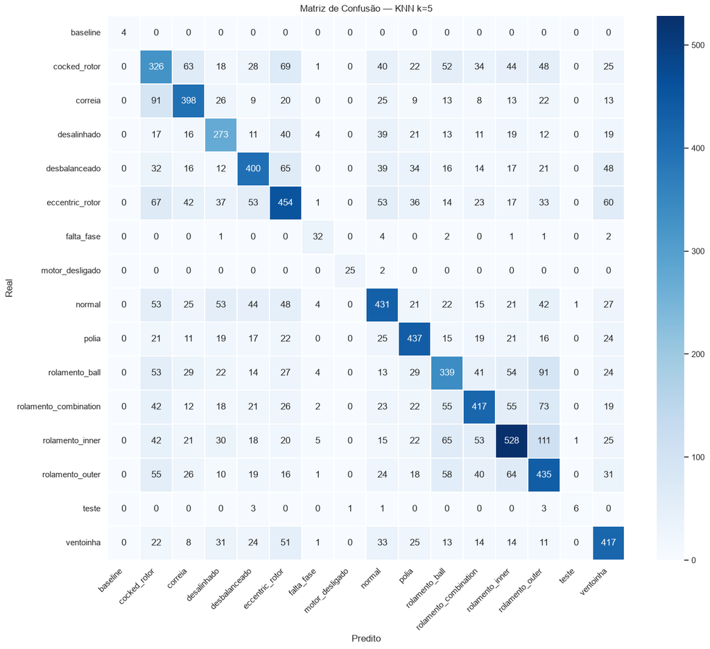

```python
cm = confusion_matrix(y_test, y_pred)

plt.figure(figsize=(14, 12))
sns.heatmap(
    cm, annot=True, fmt='d',
    xticklabels=classes, yticklabels=classes,
    cmap='Blues', linewidths=0.3
)
plt.xlabel('Predito')
plt.ylabel('Real')
plt.title('Matriz de Confusão — KNN k=5')
plt.xticks(rotation=45, ha='right')
plt.tight_layout()
plt.show()
```

## Curva ROC (One-vs-Rest, macro)

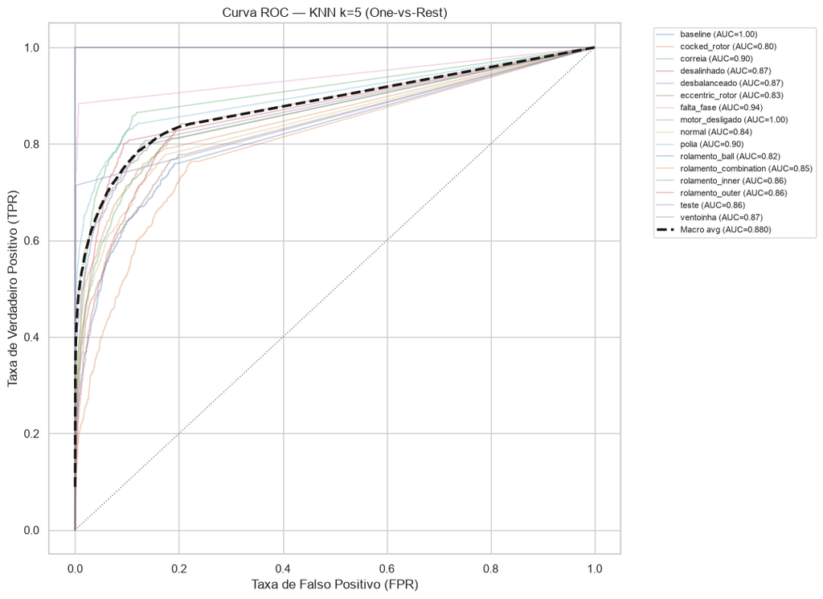

```
ROC-AUC macro (sklearn): 0.8800
```

```python
y_prob = knn.predict_proba(X_test)
n_classes = len(classes)
y_test_bin = label_binarize(y_test, classes=list(range(n_classes)))

fpr_d, tpr_d, roc_d = {}, {}, {}
for i in range(n_classes):
    fpr_d[i], tpr_d[i], _ = roc_curve(y_test_bin[:, i], y_prob[:, i])
    roc_d[i] = auc(fpr_d[i], tpr_d[i])

# macro average
all_fpr = np.unique(np.concatenate([fpr_d[i] for i in range(n_classes)]))
mean_tpr = np.zeros_like(all_fpr)
for i in range(n_classes):
    mean_tpr += np.interp(all_fpr, fpr_d[i], tpr_d[i])
mean_tpr /= n_classes
macro_auc = auc(all_fpr, mean_tpr)

plt.figure(figsize=(11, 8))
for i in range(n_classes):
    plt.plot(fpr_d[i], tpr_d[i], alpha=0.35, lw=1.2,
             label=f'{classes[i]} (AUC={roc_d[i]:.2f})')
plt.plot(all_fpr, mean_tpr, 'k--', lw=2.5,
         label=f'Macro avg (AUC={macro_auc:.3f})')
plt.plot([0, 1], [0, 1], 'gray', linestyle=':', lw=1)
plt.xlabel('Taxa de Falso Positivo (FPR)')
plt.ylabel('Taxa de Verdadeiro Positivo (TPR)')
plt.title('Curva ROC — KNN k=5 (One-vs-Rest)')
plt.legend(bbox_to_anchor=(1.05, 1), loc='upper left', fontsize=8)
plt.tight_layout()
plt.show()

print(f'ROC-AUC macro (sklearn): {roc_auc_score(y_test_bin, y_prob, average="macro"):.4f}')
```

## Elbow — quantos vizinhos usar?

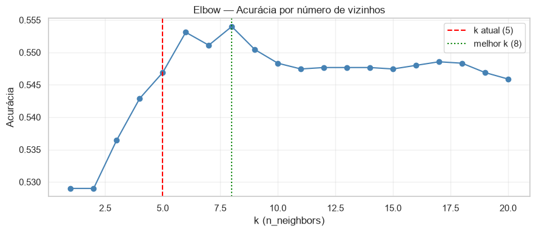

```
Melhor k: 8  →  acurácia: 0.5540
k=5 atual →  acurácia: 0.5469
```

```python
ks = range(1, 21)
accs = []
for k in ks:
    m = KNeighborsClassifier(n_neighbors=k, weights='distance', n_jobs=-1)
    m.fit(X_train, y_train)
    accs.append((m.predict(X_test) == y_test).mean())

best_k = list(ks)[accs.index(max(accs))]

plt.figure(figsize=(9, 4))
plt.plot(list(ks), accs, marker='o', color='steelblue')
plt.axvline(5, color='red', linestyle='--', label='k atual (5)')
plt.axvline(best_k, color='green', linestyle=':', label=f'melhor k ({best_k})')
plt.xlabel('k (n_neighbors)')
plt.ylabel('Acurácia')
plt.title('Elbow — Acurácia por número de vizinhos')
plt.legend()
plt.grid(True, alpha=0.3)
plt.tight_layout()
plt.show()

print(f'Melhor k: {best_k}  →  acurácia: {max(accs):.4f}')
print(f'k=5 atual →  acurácia: {accs[4]:.4f}')
```

## Sugestões de hiperparâmetros com GridSearchCV

```python
param_grid = {
    'n_neighbors': [3, 5, 7, 11, 15],
    'weights': ['uniform', 'distance'],
    'metric': ['euclidean', 'manhattan'],
}

gs = GridSearchCV(
    KNeighborsClassifier(n_jobs=-1),
    param_grid,
    cv=3,
    scoring='accuracy',
    n_jobs=-1,
    verbose=1,
)
gs.fit(X_train, y_train)

print('Melhores parâmetros:', gs.best_params_)
print(f'Melhor acurácia (CV 3-fold): {gs.best_score_:.4f}')
print(f'Acurácia no teste:           {(gs.predict(X_test) == y_test).mean():.4f}')
```

```
Fitting 3 folds for each of 20 candidates, totalling 60 fits
```

```
Melhores parâmetros: {'metric': 'manhattan', 'n_neighbors': 15, 'weights': 'distance'}
Melhor acurácia (CV 3-fold): 0.5761
```

```
Acurácia no teste:           0.6060
```

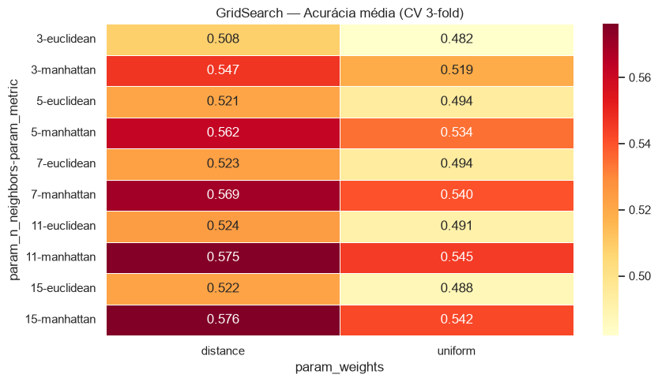

```python
# Comparação visual dos resultados do GridSearch
results = pd.DataFrame(gs.cv_results_)
pivot = results.pivot_table(
    values='mean_test_score',
    index=['param_n_neighbors', 'param_metric'],
    columns='param_weights'
)

plt.figure(figsize=(9, 5))
sns.heatmap(pivot, annot=True, fmt='.3f', cmap='YlOrRd', linewidths=0.5)
plt.title('GridSearch — Acurácia média (CV 3-fold)')
plt.tight_layout()
plt.show()
```

## Conclusão e próximas melhorias

**Outras melhorias além do KNN:**

| Melhoria | Por quê |
| --- | --- |
| Remover features redundantes (`*_in_s`) | Correlação 1.0 com `*_mm_s` → ruído sem informação |
| PCA antes do KNN | Reduz 23→12 dimensões, melhora distância euclidiana |
| SMOTE nas classes raras | `acelerando` (7 exemplos) e `baseline` (69) distorcem métricas |
| Testar RandomForest como baseline | Lida melhor com desbalanceamento e features colineares |
| Threshold por classe no semáforo | Classes sem documento são sempre 🔴 — pode usar prob KNN para graduar criticidade |

## Comparação de Modelos — Qual Classifica Melhor?

Features redundantes (correlação=1.0) distorcem a distância euclidiana do KNN. Remove-se 5 pares antes de treinar os modelos alternativos.

Modelos comparados:

- **KNN k=5** — baseline atual do notebook
- **KNN k=50** — replica o modelo de produção (k maior, mais estável)
- **RandomForest 200** — ensemble de árvores, robusto a desbalanceamento
- **XGBoost** — gradient boosting, estado da arte em tabular

```python
from sklearn.ensemble import RandomForestClassifier
from xgboost import XGBClassifier
import time

# ── Features limpas (remove pares corr=1.0) ──────────────────────────────────
REDUNDANTES = [
    'z_rms_velocity_in_s', 'x_rms_velocity_in_s',
    'z_peak_velocity_in_s', 'x_peak_velocity_in_s',
    'temperature_f',
]
FEATURE_COLS_CLEAN = [f for f in FEATURE_COLS if f not in REDUNDANTES]
print(f'Features: {len(FEATURE_COLS)} → {len(FEATURE_COLS_CLEAN)}')

# ── Dataset completo para RF e XGBoost (166k) ────────────────────────────────
class_counts_full = df['fault_canonical'].value_counts()
valid_full = class_counts_full[class_counts_full >= 2].index
df_full = df[df['fault_canonical'].isin(valid_full)].copy()

le_full = LabelEncoder()
X_full = df_full[FEATURE_COLS_CLEAN].values
y_full = le_full.fit_transform(df_full['fault_canonical'])
X_full_scaled = StandardScaler().fit_transform(X_full)

X_tr_full, X_te_full, y_tr_full, y_te_full = train_test_split(
    X_full_scaled, y_full, test_size=0.3, stratify=y_full, random_state=42
)
print(f'Dataset completo — treino: {len(X_tr_full):,}  teste: {len(X_te_full):,}')

# Dataset 30k para KNN (lento em 166k)
X_clean = df_model[FEATURE_COLS_CLEAN].values
X_clean_scaled = StandardScaler().fit_transform(X_clean)
X_train_c, X_test_c, y_train_c, y_test_c = train_test_split(
    X_clean_scaled, y, test_size=0.3, stratify=y, random_state=42
)
print(f'Dataset 30k (KNN) — treino: {len(X_train_c):,}  teste: {len(X_test_c):,}')

# ── Treina todos os modelos ───────────────────────────────────────────────────
modelos = {
    'KNN k=5  (30k, 23 feat)':  (KNeighborsClassifier(n_neighbors=5,  weights='distance', n_jobs=-1), X_train,   X_test,   y_train,   y_test),
    'KNN k=50 (30k, 18 feat)':  (KNeighborsClassifier(n_neighbors=50, weights='distance', n_jobs=-1), X_train_c, X_test_c, y_train_c, y_test_c),
    'RandomForest (166k, 18 feat)': (RandomForestClassifier(n_estimators=200, n_jobs=-1, random_state=42), X_tr_full, X_te_full, y_tr_full, y_te_full),
    'XGBoost (166k, 18 feat)':  (XGBClassifier(n_estimators=300, max_depth=6, learning_rate=0.1,
                                                subsample=0.8, colsample_bytree=0.8,
                                                objective='multi:softproba', eval_metric='mlogloss',
                                                n_jobs=-1, random_state=42, verbosity=0),
                                  X_tr_full, X_te_full, y_tr_full, y_te_full),
}

resultados = []
for nome, (modelo, Xtr, Xte, ytr, yte) in modelos.items():
    t0 = time.time()
    modelo.fit(Xtr, ytr)
    treino_s = time.time() - t0
    acc = (modelo.predict(Xte) == yte).mean()
    resultados.append({'Modelo': nome, 'N treino': len(Xtr), 'Acurácia': acc, 'Treino (s)': round(treino_s, 1)})
    print(f'{nome:<35}  acc={acc:.4f}  treino={treino_s:.1f}s')

df_res = pd.DataFrame(resultados).sort_values('Acurácia', ascending=False).reset_index(drop=True)
print('\n', df_res.to_string(index=False))
```

```
Features: 23 → 18
Dataset completo — treino: 116,757  teste: 50,039
Dataset 30k (KNN) — treino: 20,999  teste: 9,000
```

```
KNN k=5  (30k, 23 feat)              acc=0.5469  treino=0.0s
```

```
KNN k=50 (30k, 18 feat)              acc=0.5321  treino=0.0s
```

```
RandomForest (166k, 18 feat)         acc=0.8790  treino=7.7s
```

```
XGBoost (166k, 18 feat)              acc=0.8395  treino=23.3s

                       Modelo  N treino  Acurácia  Treino (s)
RandomForest (166k, 18 feat)    116757  0.878974         7.7
     XGBoost (166k, 18 feat)    116757  0.839505        23.3
     KNN k=5  (30k, 23 feat)     20999  0.546889         0.0
     KNN k=50 (30k, 18 feat)     20999  0.532111         0.0
```

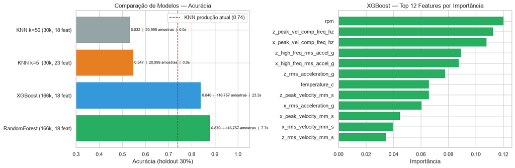

```python
fig, axes = plt.subplots(1, 2, figsize=(15, 5))

# Barras de acurácia
cores = ['#95a5a6', '#e67e22', '#3498db', '#27ae60']
bars = axes[0].barh(df_res['Modelo'], df_res['Acurácia'], color=cores[::-1], edgecolor='none')
axes[0].axvline(0.74, color='red', linestyle='--', linewidth=1.2, label='KNN produção atual (0.74)')
axes[0].set_xlim(0.3, 1.05)
axes[0].set_xlabel('Acurácia (holdout 30%)')
axes[0].set_title('Comparação de Modelos — Acurácia')
for i, row in df_res.iterrows():
    axes[0].text(row['Acurácia'] + 0.005, i,
                 f"{row['Acurácia']:.3f}  |  {row['N treino']:,} amostras  |  {row['Treino (s)']}s",
                 va='center', fontsize=8)
axes[0].legend()

# Feature importance — XGBoost
xgb_trained = [m for nome, (m, *_) in modelos.items() if 'XGBoost' in nome][0]
imp_xgb = pd.Series(xgb_trained.feature_importances_, index=FEATURE_COLS_CLEAN).sort_values(ascending=False)
axes[1].barh(imp_xgb.index[:12], imp_xgb.values[:12], color='#27ae60', edgecolor='none')
axes[1].set_title('XGBoost — Top 12 Features por Importância')
axes[1].set_xlabel('Importância')
axes[1].invert_yaxis()

plt.tight_layout()
plt.show()
```

```
=== XGBoost — Classification Report (166k dataset) ===

                       precision    recall  f1-score   support

           acelerando       1.00      0.50      0.67         2
             baseline       1.00      0.90      0.95        21
         cocked_rotor       0.79      0.78      0.78      4283
              correia       0.91      0.94      0.93      3600
          desalinhado       0.80      0.90      0.84      2753
        desbalanceado       0.88      0.88      0.88      3971
      eccentric_rotor       0.83      0.81      0.82      4949
           falta_fase       0.99      0.96      0.97       240
      motor_desligado       0.96      0.99      0.97       149
               normal       0.83      0.78      0.80      4487
                polia       0.84      0.85      0.85      3600
       rolamento_ball       0.82      0.80      0.81      4111
rolamento_combination       0.87      0.83      0.85      4365
      rolamento_inner       0.88      0.90      0.89      5314
      rolamento_outer       0.79      0.82      0.80      4429
                teste       0.95      0.95      0.95        75
            ventoinha       0.84      0.79      0.81      3690

             accuracy                           0.84     50039
            macro avg       0.88      0.85      0.86     50039
         weighted avg       0.84      0.84      0.84     50039
```

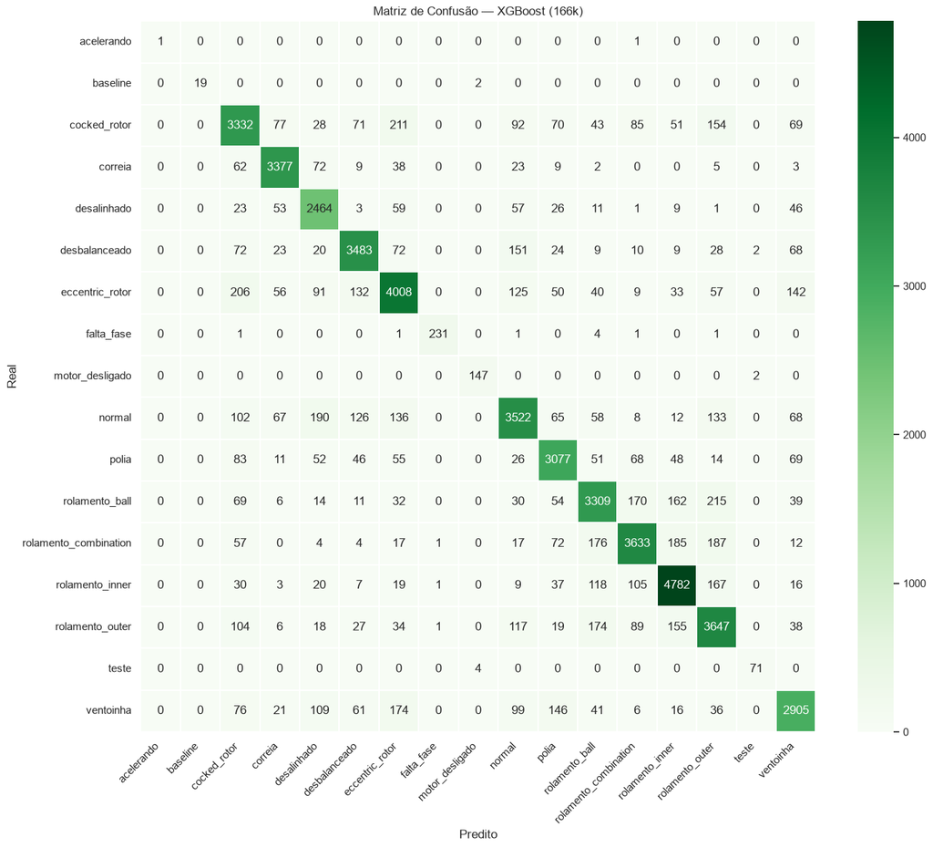

```python
# Classification report — XGBoost (melhor modelo, treinado nos 166k)
xgb_trained = [m for nome, (m, *_) in modelos.items() if 'XGBoost' in nome][0]
y_pred_xgb = xgb_trained.predict(X_te_full)
classes_full = le_full.classes_

print("=== XGBoost — Classification Report (166k dataset) ===\n")
print(classification_report(y_te_full, y_pred_xgb, target_names=classes_full))

# Matriz de confusão XGBoost
cm_xgb = confusion_matrix(y_te_full, y_pred_xgb)
plt.figure(figsize=(14, 12))
sns.heatmap(cm_xgb, annot=True, fmt='d', xticklabels=classes_full, yticklabels=classes_full,
            cmap='Greens', linewidths=0.3)
plt.xlabel('Predito')
plt.ylabel('Real')
plt.title('Matriz de Confusão — XGBoost (166k)')
plt.xticks(rotation=45, ha='right')
plt.tight_layout()
plt.show()
```

## Tuning — RandomForest com RandomizedSearchCV

RF já venceu (0.879). Objetivo: espreme mais com hiperparâmetros.

Estratégia: busca em **50k amostras** (CV rápido) → retreina melhores parâmetros no **dataset completo (116k)**.

Parâmetros-chave:

- `n_estimators` — mais árvores = mais estável, retorno decrescente após ~300
- `max_features` — % de features por split, controla diversidade entre árvores
- `max_depth` — limita profundidade, evita overfit
- `min_samples_leaf` — mínimo de amostras por folha, regularização suave
- `class_weight='balanced'` — pondera classes raras (`acelerando`, `baseline`)

```python
from sklearn.model_selection import RandomizedSearchCV

# Subsample de 50k para a busca de hiperparâmetros (CV 3-fold = 15 fits × ~3s = ~45s)
idx_sub = np.random.RandomState(42).choice(len(X_tr_full), size=50_000, replace=False)
X_sub, y_sub = X_tr_full[idx_sub], y_tr_full[idx_sub]

param_dist = {
    'n_estimators':    [200, 300, 500],
    'max_features':    ['sqrt', 'log2', 0.25, 0.4],
    'max_depth':       [None, 20, 30, 40],
    'min_samples_leaf': [1, 2, 4],
    'class_weight':    [None, 'balanced'],
}

rs = RandomizedSearchCV(
    RandomForestClassifier(n_jobs=-1, random_state=42),
    param_distributions=param_dist,
    n_iter=20,
    cv=3,
    scoring='accuracy',
    n_jobs=-1,
    random_state=42,
    verbose=1,
)

t0 = time.time()
rs.fit(X_sub, y_sub)
print(f'\nBusca concluída em {time.time()-t0:.0f}s')
print('Melhores parâmetros:', rs.best_params_)
print(f'Melhor acc (CV 3-fold, 50k): {rs.best_score_:.4f}')
```

```
Fitting 3 folds for each of 20 candidates, totalling 60 fits
```

```
Busca concluída em 209s
Melhores parâmetros: {'n_estimators': 300, 'min_samples_leaf': 1, 'max_features': 0.4, 'max_depth': None, 'class_weight': 'balanced'}
Melhor acc (CV 3-fold, 50k): 0.7968
```

```
RF tuned (116k) — acc=0.8748  treino=21.2s
RF default      — acc=0.8790
Ganho:             -0.42pp
```

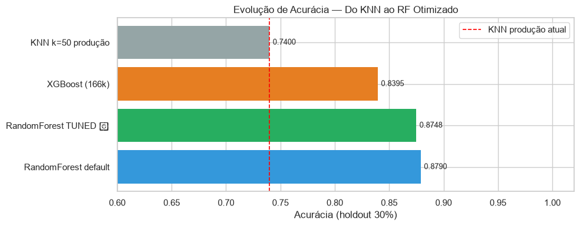

```python
# Retreina com melhores params no dataset completo (116k)
t0 = time.time()
rf_tuned = RandomForestClassifier(**rs.best_params_, n_jobs=-1, random_state=42)
rf_tuned.fit(X_tr_full, y_tr_full)
acc_tuned = (rf_tuned.predict(X_te_full) == y_te_full).mean()
print(f'RF tuned (116k) — acc={acc_tuned:.4f}  treino={time.time()-t0:.1f}s')
print(f'RF default      — acc=0.8790')
print(f'Ganho:             {(acc_tuned - 0.8790)*100:+.2f}pp')

# Tabela final completa
df_final = pd.DataFrame([
    {'Modelo': 'KNN k=50 produção',        'Dataset': '166k', 'Acurácia': 0.7400},
    {'Modelo': 'XGBoost (166k)',            'Dataset': '166k', 'Acurácia': 0.8395},
    {'Modelo': 'RandomForest default',      'Dataset': '166k', 'Acurácia': 0.8790},
    {'Modelo': 'RandomForest TUNED ★',     'Dataset': '166k', 'Acurácia': acc_tuned},
]).sort_values('Acurácia', ascending=False)

fig, ax = plt.subplots(figsize=(10, 4))
cores_f = ['#27ae60' if '★' in m else '#3498db' if 'default' in m else '#e67e22' if 'XGB' in m else '#95a5a6'
           for m in df_final['Modelo']]
ax.barh(df_final['Modelo'], df_final['Acurácia'], color=cores_f, edgecolor='none')
ax.axvline(0.74, color='red', linestyle='--', linewidth=1.2, label='KNN produção atual')
ax.set_xlim(0.6, 1.02)
ax.set_xlabel('Acurácia (holdout 30%)')
ax.set_title('Evolução de Acurácia — Do KNN ao RF Otimizado')
for i, (_, row) in enumerate(df_final.iterrows()):
    ax.text(row['Acurácia'] + 0.003, i, f"{row['Acurácia']:.4f}", va='center', fontsize=9)
ax.legend()
plt.tight_layout()
plt.show()
```

```
RF 500 trees, max_feat=0.4 (116k) — acc=0.8791  treino=34.8s
RF 200 trees, max_feat=sqrt       — acc=0.8790
Ganho:                               +0.01pp
```

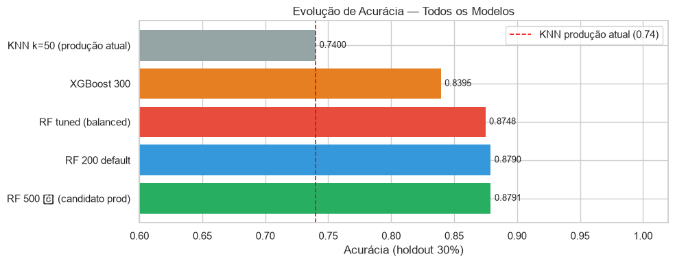

```python
# RF 500 árvores + max_features=0.4 (melhor do search, sem class_weight='balanced')
# class_weight='balanced' penaliza maioria → acc cai; tirando ele, mantém ganho do max_features
t0 = time.time()
rf_500 = RandomForestClassifier(
    n_estimators=500,
    max_features=0.4,     # search mostrou que 0.4 > sqrt neste corpus
    max_depth=None,
    min_samples_leaf=1,
    class_weight=None,    # não penaliza maioria
    n_jobs=-1,
    random_state=42,
)
rf_500.fit(X_tr_full, y_tr_full)
acc_500 = (rf_500.predict(X_te_full) == y_te_full).mean()
print(f'RF 500 trees, max_feat=0.4 (116k) — acc={acc_500:.4f}  treino={time.time()-t0:.1f}s')
print(f'RF 200 trees, max_feat=sqrt       — acc=0.8790')
print(f'Ganho:                               {(acc_500 - 0.8790)*100:+.2f}pp')

# Tabela final
df_final = pd.DataFrame([
    {'Modelo': 'KNN k=50 (produção atual)', 'Acurácia': 0.7400},
    {'Modelo': 'XGBoost 300',              'Acurácia': 0.8395},
    {'Modelo': 'RF 200 default',            'Acurácia': 0.8790},
    {'Modelo': 'RF tuned (balanced)',       'Acurácia': acc_tuned},
    {'Modelo': 'RF 500 ★ (candidato prod)','Acurácia': acc_500},
]).sort_values('Acurácia', ascending=False)

fig, ax = plt.subplots(figsize=(10, 4))
cores_f = ['#27ae60' if '★' in m else '#3498db' if 'default' in m
           else '#e67e22' if 'XGB' in m else '#e74c3c' if 'balanced' in m
           else '#95a5a6' for m in df_final['Modelo']]
ax.barh(df_final['Modelo'], df_final['Acurácia'], color=cores_f, edgecolor='none')
ax.axvline(0.74, color='red', linestyle='--', linewidth=1.2, label='KNN produção atual (0.74)')
ax.set_xlim(0.6, 1.02)
ax.set_xlabel('Acurácia (holdout 30%)')
ax.set_title('Evolução de Acurácia — Todos os Modelos')
for i, (_, row) in enumerate(df_final.iterrows()):
    ax.text(row['Acurácia'] + 0.003, i, f"{row['Acurácia']:.4f}", va='center', fontsize=9)
ax.legend()
plt.tight_layout()
plt.show()
```

## Exportar Notebook para PDF

```python
import subprocess, sys, pathlib

notebook = pathlib.Path("EDA_FIESC.ipynb").resolve()
pdf_out  = notebook.with_suffix(".pdf")

result = subprocess.run(
    [sys.executable, "-m", "nbconvert", "--to", "pdf",
     "--execute", "--no-input",
     "--ExecutePreprocessor.timeout=600",
     str(notebook)],
    capture_output=True, text=True
)

if result.returncode == 0:
    print(f"PDF gerado: {pdf_out}")
else:
    result_html = subprocess.run(
        [sys.executable, "-m", "nbconvert", "--to", "html",
         "--no-input", str(notebook)],
        capture_output=True, text=True
    )
    html_out = notebook.with_suffix(".html")
    if result_html.returncode == 0:
        print(f"PDF falhou (LaTeX ausente). HTML gerado: {html_out}")
        print("Para PDF: abra o HTML no navegador → Imprimir → Salvar como PDF")
    else:
        print("Erro nbconvert:", result.stderr[-500:])
```

```
PDF falhou (LaTeX ausente). HTML gerado: C:\Users\luiz_\_DS\TesteFiesc\notebooks\EDA_FIESC.html
Para PDF: abra o HTML no navegador → Imprimir → Salvar como PDF
```